# ALY6040_Project_EDA

Ashna Solkar and Yuhong Tao

2025-04-20

1. Environment Reset Code

```r
rm(list=ls())
```

2. Libraries Used

```r
library(readr)
library(dplyr)
library(viridis)
```

```r
library(ggplot2)
library(corrplot)
library(forcats)
```

3. Loading Dataset

```r
# Loading dataset
data_2024 <- read_csv("Employee_Salaries_-_2024.csv")
```

4. Loading additional dataset and combining into original data set

```r
data_2019 <- read_csv("Employee_Salaries_-_2019.csv")
data_2020 <- read_csv("Employee_Salaries_-_2020.csv")
data_2021 <- read_csv("Employee_Salaries_-_2021.csv")
data_2022 <- read_csv("Employee_Salaries_-_2022.csv")
data_2023 <- read_csv("Employee_Salaries_-_2023.csv")
# Adding new column Year in each dataset
data_2019 <- mutate(data_2019, Year = 2019)
data_2020 <- mutate(data_2020, Year = 2020)
data_2021 <- mutate(data_2021, Year = 2021)
data_2022 <- mutate(data_2022, Year = 2022)
data_2023 <- mutate(data_2023, Year = 2023)
data_2024 <- mutate(data_2024, Year = 2024)

# Changing the column names in all the dataset with standardized names
column_names <- c("Department", "Department Name", "Division", "Gender", "Base Salary", "Overtime Pay", "Longevity Pay", "Grade", "Year")

data_2019 <- data_2019 %>% setNames(column_names)
data_2020 <- data_2020 %>% setNames(column_names)
data_2021 <- data_2021 %>% setNames(column_names)
data_2022 <- data_2022 %>% setNames(column_names)
data_2023 <- data_2023 %>% setNames(column_names)
data_2024 <- data_2024 %>% setNames(column_names)

# Combining the dataset
data <- rbind(data_2024, data_2019, data_2020, data_2021, data_2022, data_2023)
```

1. Data Exploration

```r
# View the dataset
View(data)
```

1.1. Understanding the Data Structure

```r
# Display internal structure and summary of statistics of the dataset
glimpse(data)
```

```
## Rows: 60,711
## Columns: 9
## $ Department        <chr> "ABS", "CUS", "DGS", "CEX", "HHS", "OAG", "COR", "HH…
## $ `Department Name` <chr> "Alcohol Beverage Services", "Community Use of Publi…
## $ Division          <chr> "ABS 85 IT Administration", "CUS 70 Finance and Admi…
## $ Gender            <chr> "M", "F", "F", "F", "F", "F", "F", "F", "F", "F", "F…
## $ `Base Salary`     <dbl> 169555.0, 141876.9, 87523.0, 207000.0, 91392.0, 1088…
## $ `Overtime Pay`    <dbl> 0.00, 0.00, 748.37, 0.00, 0.00, 0.00, 0.00, 0.00, 0.…
## $ `Longevity Pay`   <dbl> 0.00, 0.00, 2701.48, 0.00, 5733.27, 3361.18, 0.00, 8…
## $ Grade             <chr> "M3", "M3", "16", "EX2", "N17", "N21", "M3", "N25", …
## $ Year              <dbl> 2024, 2024, 2024, 2024, 2024, 2024, 2024, 2024, 2024…
```

```r
summary(data)
```

```
##   Department        Department Name      Division            Gender
##  Length:60711       Length:60711       Length:60711       Length:60711
##  Class :character   Class :character   Class :character   Class :character
##  Mode  :character   Mode  :character   Mode  :character   Mode  :character
##
##
##
##
##   Base Salary      Overtime Pay    Longevity Pay      Grade
##  Min.   :  4816   Min.   :     0   Min.   :    0   Length:60711
##  1st Qu.: 63500   1st Qu.:     0   1st Qu.:    0   Class :character
##  Median : 83154   Median :  1224   Median :    0   Mode  :character
##  Mean   : 85648   Mean   :  8076   Mean   : 1468
##  3rd Qu.:104145   3rd Qu.:  9691   3rd Qu.: 2047
##  Max.   :306900   Max.   :261311   Max.   :20957
##                   NA's   :8578     NA's   :15147
##       Year
##  Min.   :2019
##  1st Qu.:2020
##  Median :2022
##  Mean   :2022
##  3rd Qu.:2023
##  Max.   :2024
##
```

1.2. Identifying Length of unique values in each variable

```r
# Length of unique values recorded under each variable
cat("Number of Unique Values in each Variable: \n")
```

```
## Number of Unique Values in each Variable:
```

```r
cat("Department:",length(unique(data$Department)), "\n")
```

```
## Department: 44
```

```r
cat("Department Name:",length(unique(data$`Department Name`)), "\n")
```

```
## Department Name: 44
```

```r
cat("Division:",length(unique(data$Division)), "\n")
```

```
## Division: 1507
```

```r
cat("Gender:",length(unique(data$Gender)), "\n")
```

```
## Gender: 2
```

```r
cat("Base Salary:",length(unique(data$`Base Salary`)), "\n")
```

```
## Base Salary: 17943
```

```r
cat("Overtime Pay:",length(unique(data$`Overtime Pay`)), "\n")
```

```
## Overtime Pay: 33361
```

```r
cat("Longevity Pay",length(unique(data$`Longevity Pay`)), "\n")
```

```
## Longevity Pay 5437
```

```r
cat("Grade:",length(unique(data$Grade)), "\n")
```

```
## Grade: 123
```

This tells us that Department column records abbreviated values whose full forms can be found in Department.Names. Each Department has one or more Division. There are only two types of values recorded under Gender. Compensation related variables such as Base.Salary, Overtime.Pay, and Longevity.Pay are numeric values hence, more evaluation can be conducted using statistic function. The Grade column contains numerous unique values, suggesting potential relationships with other variables in the data set. Grades may vary across Departments and/or Divisions, and their hierarchical levels can potentially be inferred using compensation-related variables.

2. Missing Values & Duplicate Rows

```r
# Considering possible representational missing values by creating a vector called missing_values
missing_values <- c("", "NA", "NULL", "-99", "-999")

# Replacing every possible missing values by NA
data[data %in% missing_values] <- NA

# Counting all the NA's in each variable
cat("Missing values per Column:\n")
```

```
## Missing values per Column:
```

```r
colSums(is.na(data))
```

```
##      Department Department Name        Division          Gender     Base Salary
##               0               0               0               0               0
##    Overtime Pay   Longevity Pay           Grade            Year
##            8578           15147              61               0
```

```r
# Counting all Duplicate rows
cat("Number of Duplicate Rows:", sum(duplicated(data)), "\n")
```

```
## Number of Duplicate Rows: 3636
```

3. Data Cleaning

3.1. Handling Duplicate Rows and Missing Values

```r
# Removing Duplicate Rows
data_clean <- data %>% distinct()

# Rechecking missing values in Grade column affected
sum(is.na(data_clean$Grade))
```

```
## [1] 39
```

This means, 22 records containing missing values in Grade variable were duplicate. (61 minus 39). Hence, investigating the missing rows further:

```r
# Filtering data with missing values in Grade column and storing in object called missing_grade_data
missing_grade_data <- data_clean %>% filter(is.na(Grade))
missing_grade_data
```

| Department | Department Name | Division | Gender | Base Salary | Overtime Pay | Longevity Pay | Grade | Year |
| --- | --- | --- | --- | --- | --- | --- | --- | --- |
| CEX | Offices of the County Executive | CEX 15 County Executive | M | 239382.74 | 0 | 0.00 | NA | 2024 |
| SHF | Sheriff's Office | SHF 48 Administration | F | 180619.12 | 0 | 11726.95 | NA | 2024 |
| CCL | County Council | CCL 01 Council Members and Staff | M | 167172.18 | 0 | 0.00 | NA | 2024 |
| OAG | Office of Agriculture | OAG 78 Soil Conservation | M | 11147.24 | 0 | 0.00 | NA | 2024 |
| SHF | Sheriff's Office | SHF 48 Administration | M | 200546.72 | 0 | 0.00 | NA | 2024 |
| HHS | Department of Health and Human Services | HHS 60 Director's Office Division | M | 199710.82 | 0 | 0.00 | NA | 2024 |
| CCL | County Council | CCL 01 Council Members and Staff | F | 167172.18 | 0 | 0.00 | NA | 2024 |
| CCL | County Council | CCL 01 Council Members and Staff | F | 183889.40 | 0 | 0.00 | NA | 2024 |
| HHS | Department of Health and Human Services | HHS 60 Public Health Services Division | F | 217451.00 | 0 | 0.00 | NA | 2024 |
| SHF | Sheriff's Office | SHF 48 Administration | M | 180619.12 | 0 | 0.00 | NA | 2024 |

[output cut: 29 more lines]

Observations: Of the 39 rows with missing Grade, have no Overtime Pay and Longevity Pay, except for 2 row with Longevity Pay. Moreover it spans across various departments like CEX, ZAH, SHF, OLO, CCL(majority), OAG, and HHS. Base Salary is not zero. Interpretation & Decision: Some entries may represent non-graded or temporary roles, but they still hold analytical value. Therefore, missing values in the Grade column will be retained and replaced with “Unknown” to maintain clarity and preserve these records for potential further analysis. Additionally, missing values in Overtime Pay and Longevity Pay will be replaced with 0, interpreting the blanks as instances where no payment was made in these components.

```r
# Replacing NA values in Grade variable with Unknown
data_clean$Grade[is.na(data_clean$Grade)] <- "Unknown"
data_clean$`Overtime Pay`[is.na(data_clean$`Overtime Pay`)] <- 0.00
data_clean$`Longevity Pay`[is.na(data_clean$`Longevity Pay`)] <- 0.00

# Verifying changes
colSums(is.na(data_clean))
```

```
##      Department Department Name        Division          Gender     Base Salary
##               0               0               0               0               0
##    Overtime Pay   Longevity Pay           Grade            Year
##               0               0               0               0
```

3.2. Converting Categorical Values to Factors

The variables Department, Department Name, Division, Gender, and Grade are categorical in nature and should be converted to factors for accurate analysis.

Department, Department Name, Division, Gender are nominal categorical variables. Grade is an ordinal categorical variable, since grades are generally represented as hierarchical levels. However, further analysis is required to understand the ordering based on compensation or role structure.

```r
# Converting variables to nominal
data_clean <- data_clean %>%
  mutate(
    Department = factor(Department),
    `Department Name` = factor(`Department Name`),
    Division = factor(Division),
    Gender = factor(Gender)
  )
```

```r
# Summary statistics of cleaned dataset
summary(data_clean)
```

```
##    Department                                   Department Name
##  POL    :10478   Department of Police                   :10478
##  HHS    : 9228   Department of Health and Human Services: 9228
##  FRS    : 8111   Fire and Rescue Services               : 8111
##  DOT    : 7827   Department of Transportation           : 7827
##  COR    : 3135   Correction and Rehabilitation          : 3135
##  LIB    : 2331   Department of Public Libraries         : 2331
##  (Other):15965   (Other)                                :15965
##                                  Division     Gender     Base Salary
##  DOT 50 Transit Gaithersburg Ride On : 1124   F:22999   Min.   :  4816
##  Transit Gaithersburg Ride On        :  987   M:34076   1st Qu.: 63932
##  DOT 50 Transit Silver Spring Ride On:  931             Median : 82998
##  HHS 60 School Health Services       :  905             Mean   : 85754
##  Transit Silver Spring Ride On       :  860             3rd Qu.:103034
##  School Health Services              :  802             Max.   :306900
##  (Other)                             :51466
##   Overtime Pay    Longevity Pay      Grade                Year
##  Min.   :     0   Min.   :    0   Length:57075       Min.   :2019
##  1st Qu.:     0   1st Qu.:    0   Class :character   1st Qu.:2020
##  Median :   631   Median :    0   Mode  :character   Median :2022
##  Mean   :  7374   Mean   : 1111                      Mean   :2022
##  3rd Qu.:  8394   3rd Qu.:    0                      3rd Qu.:2023
##  Max.   :261311   Max.   :20957                      Max.   :2024
##
```

4. Outlier Detection

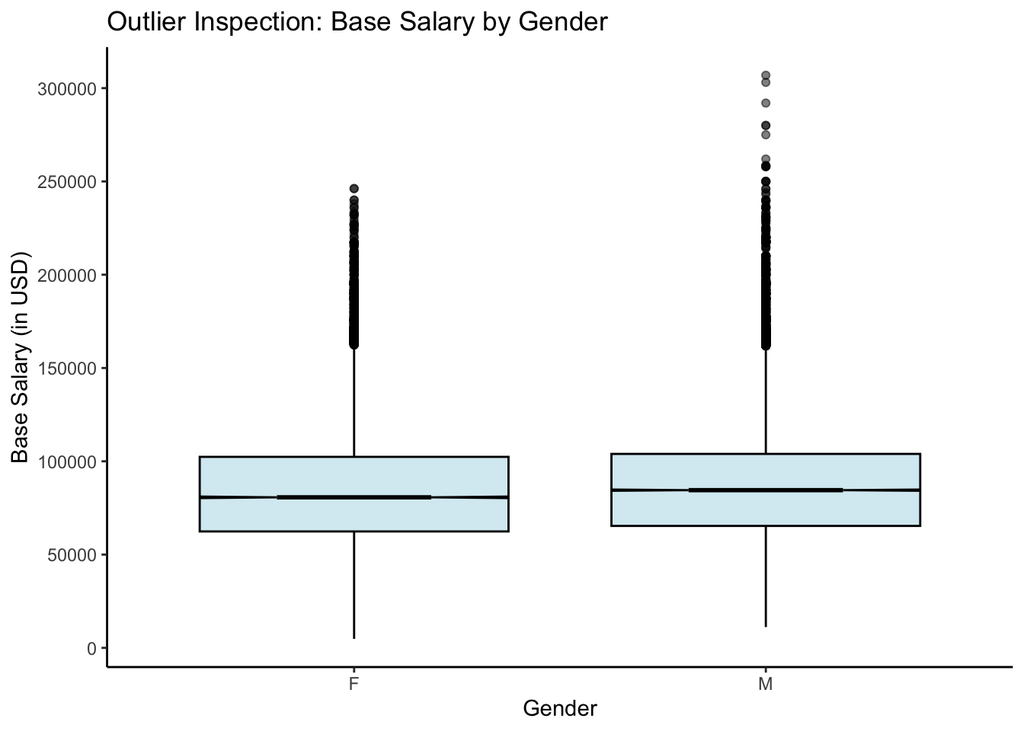

```r
# Outlier Inspection using Box plot for Base Salary by Gender
ggplot(data_clean, aes(x = Gender, y = `Base Salary`), fill = Gender) +
  geom_boxplot(fill = "lightblue", color = "black", alpha = 0.5, notch = TRUE) +
  theme_classic() +
   labs(title = "Outlier Inspection: Base Salary by Gender",
       x = "Gender",
       y = "Base Salary (in USD)") +
  scale_y_continuous(breaks = seq(0,307000,50000))
```

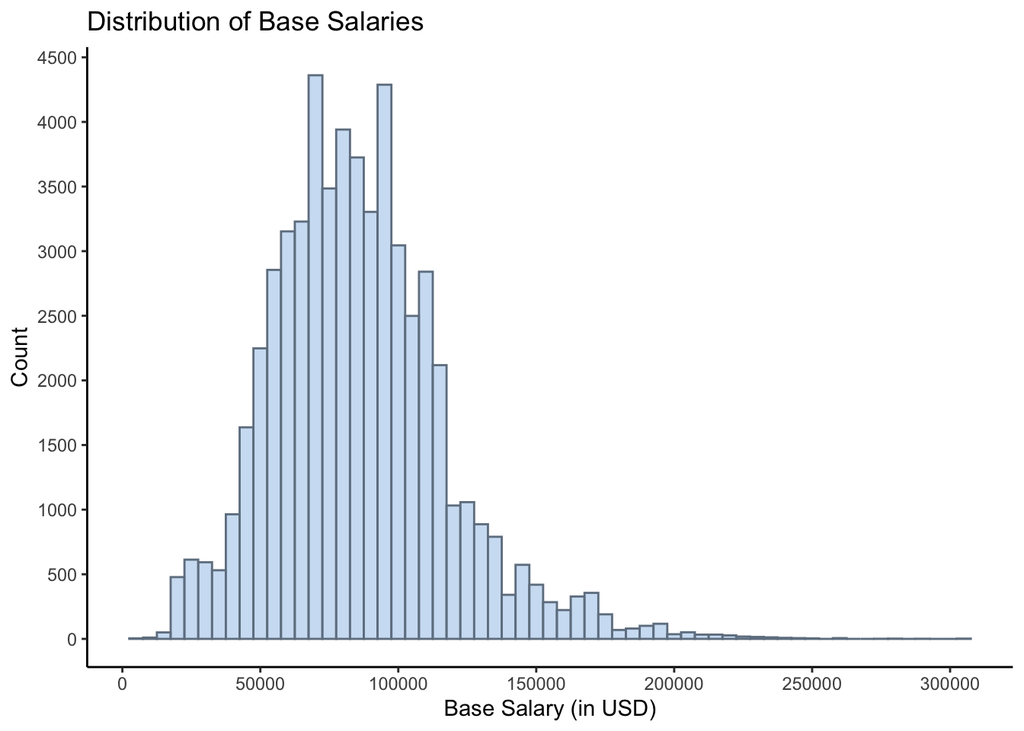

```r
# (1) Histogram of Base Salary
ggplot(data_clean, aes(x = `Base Salary`)) +
  geom_histogram(binwidth = 5000, fill = "slategray2", color = "slategrey", alpha = 0.7) +
  labs(title = "Distribution of Base Salaries", x = "Base Salary (in USD)", y = "Count") +
  scale_x_continuous(breaks = seq(0,307000,50000)) +
  scale_y_continuous(breaks = seq(0,5000,500)) +
  theme_classic()
```

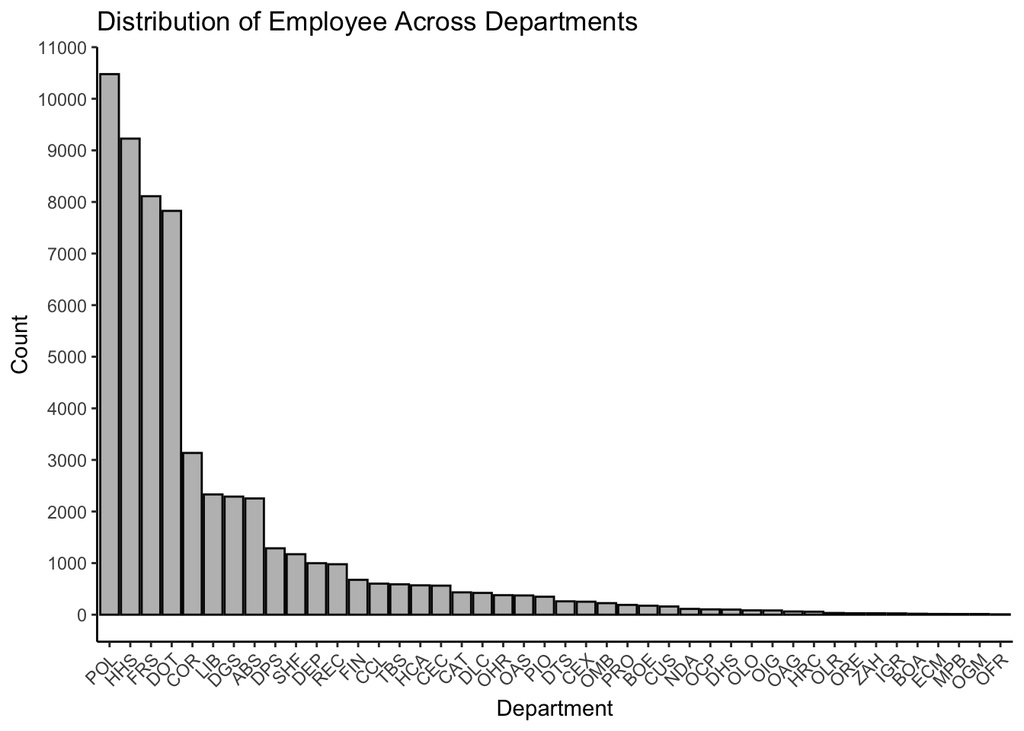

```r
# (2) Bar plot of Departments
ggplot(data_clean, aes(x = fct_infreq(Department))) +
  geom_bar(color= "gray2", fill= "gray") +
  labs(title = "Distribution of Employee Across Departments", x = "Department", y = "Count")+
  theme_classic() +
  theme(axis.text.x = element_text(angle = 45, hjust = 1)) +
  scale_y_continuous(breaks = seq(0,12000,1000))
```

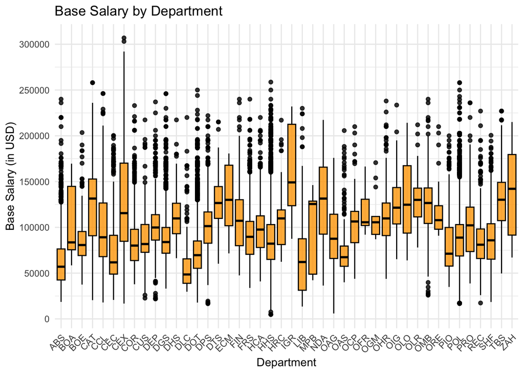

```r
# (3) Boxplot of Annual Salary by Department
ggplot(data_clean, aes(x = Department, y = `Base Salary`)) +
  geom_boxplot(fill = "orange", color = "black", alpha = 0.8) +
  labs(title = "Base Salary by Department", x = "Department", y = "Base Salary (in USD)") +
  scale_y_continuous(breaks = seq(0,307000,50000)) +
  theme_minimal() +
  theme(axis.text.x = element_text(angle = 45, hjust = 1))
```

The summary statistics of the numerical variables above appear to be skewed, likely due to the presence of outliers. Identifying these outliers within each variable is important for accurate interpretation. However, analyzing the data as a whole may exaggerate this skewness, as it aggregates compensation information across 44 different departments. Therefore, it’s essential to first identify the top departments and then conduct further analysis within those segments for more meaningful insights.

```r
# Five-number summary for Base Salary grouped by Department
dept_base_salary <- data_clean %>%
  group_by(Department) %>%
  summarise("Employee Count" = n(),
            Min = min(`Base Salary`),
            Q1 = quantile(`Base Salary`, 0.25),
            Median = median(`Base Salary`),
            Q3 = quantile(`Base Salary`, 0.75),
            Max = max(`Base Salary`)) %>%
  mutate(IQR = Q3 - Q1,
         "Lower Bound" = Q1 - 1.5*IQR,
         "Upper Bound" = Q3 + 1.5* IQR) %>%
  # Focusing on departments with employee count more than 200
  arrange(desc(`Employee Count`)) %>%
  filter(`Employee Count` >= 200)


dept_base_salary
```

| Department | Employee Count | Min | Q1 | Median | Q3 | Max | IQR | Lower Bound | Upper Bound |
| --- | --- | --- | --- | --- | --- | --- | --- | --- | --- |
| POL | 10478 | 16780.50 | 68751.00 | 88785.00 | 103034.00 | 258000.0 | 34283.00 | 17326.500 | 154458.5 |
| HHS | 9228 | 4816.28 | 64981.10 | 82192.44 | 103034.00 | 258678.0 | 38052.90 | 7901.738 | 160113.4 |
| FRS | 8111 | 33828.00 | 70540.00 | 89653.00 | 106504.00 | 240000.0 | 35964.00 | 16594.000 | 160450.0 |
| DOT | 7827 | 17847.66 | 55270.42 | 69604.00 | 85104.38 | 250000.0 | 29833.97 | 10519.467 | 129855.3 |
| COR | 3135 | 37830.00 | 63721.00 | 80086.00 | 97860.00 | 233000.0 | 34139.00 | 12512.500 | 149068.5 |
| LIB | 2331 | 13520.00 | 31301.33 | 62139.35 | 87523.00 | 230000.0 | 56221.67 | -53031.162 | 171855.5 |
| DGS | 2289 | 33118.05 | 71743.03 | 83931.00 | 99852.00 | 246000.0 | 28108.97 | 29579.575 | 142015.5 |
| ABS | 2253 | 18574.40 | 42494.21 | 57000.49 | 76419.00 | 240000.0 | 33924.79 | -8392.975 | 127306.2 |
| DPS | 1287 | 16559.02 | 82691.00 | 101350.00 | 116825.00 | 222000.0 | 34134.00 | 31490.000 | 168026.0 |
| SHF | 1172 | 18465.15 | 65234.00 | 85853.09 | 103955.00 | 200546.7 | 38721.00 | 7152.500 | 162036.5 |

[output cut: 15 more lines]

```r
# Overtime Pay grouped Department wise and arranged is descending order
dept_overtime_pay <- data_clean %>%
  group_by(Department) %>%
  summarise("Employee Count" = n(),
            Min = min(`Overtime Pay`),
            Q1 = quantile(`Overtime Pay`, 0.25),
            Median = median(`Overtime Pay`),
            Q3 = quantile(`Overtime Pay`, 0.75),
            Max = max(`Overtime Pay`)) %>%
  mutate(IQR = Q3 - Q1,
         "Lower Bound" = Q1 - 1.5*IQR,
         "Upper Bound" = Q3 + 1.5* IQR) %>%
  # Focusing on departments with employee count more than 200
  arrange(desc(`Employee Count`)) %>%
  filter(`Employee Count` >= 200)

dept_overtime_pay
```

| Department | Employee Count | Min | Q1 | Median | Q3 | Max | IQR | Lower Bound | Upper Bound |
| --- | --- | --- | --- | --- | --- | --- | --- | --- | --- |
| POL | 10478 | 0 | 197.1175 | 2991.995 | 9501.0475 | 161396.59 | 9303.9300 | -13758.7775 | 23456.9425 |
| HHS | 9228 | 0 | 0.0000 | 0.000 | 101.3625 | 77427.36 | 101.3625 | -152.0437 | 253.4062 |
| FRS | 8111 | 0 | 1290.7250 | 11515.860 | 30183.3450 | 261310.91 | 28892.6200 | -42048.2050 | 73522.2750 |
| DOT | 7827 | 0 | 1518.5600 | 6936.600 | 14426.1700 | 105803.37 | 12907.6100 | -17842.8550 | 33787.5850 |
| COR | 3135 | 0 | 1215.0200 | 11053.040 | 26892.4450 | 239720.42 | 25677.4250 | -37301.1175 | 65408.5825 |
| LIB | 2331 | 0 | 0.0000 | 0.000 | 0.0000 | 3316.75 | 0.0000 | 0.0000 | 0.0000 |
| DGS | 2289 | 0 | 0.0000 | 1002.210 | 7070.0800 | 87360.08 | 7070.0800 | -10605.1200 | 17675.2000 |
| ABS | 2253 | 0 | 11.4500 | 390.110 | 2021.2100 | 38848.77 | 2009.7600 | -3003.1900 | 5035.8500 |
| DPS | 1287 | 0 | 0.0000 | 0.000 | 517.9850 | 33098.26 | 517.9850 | -776.9775 | 1294.9625 |
| SHF | 1172 | 0 | 98.5675 | 1257.650 | 4484.4275 | 108086.80 | 4385.8600 | -6480.2225 | 11063.2175 |

[output cut: 15 more lines]

```r
# Longevity Pay grouped Department wise and arranged is descending order
dept_longevity_pay <- data_clean %>%
  group_by(Department) %>%
  summarise("Employee Count" = n(),
            Min = min(`Longevity Pay`),
            Q1 = quantile(`Longevity Pay`, 0.25),
            Median = median(`Longevity Pay`),
            Q3 = quantile(`Longevity Pay`, 0.75),
            Max = max(`Longevity Pay`)) %>%
  mutate(IQR = Q3 - Q1,
         "Lower Bound" = Q1 - 1.5*IQR,
         "Upper Bound" = Q3 + 1.5* IQR) %>%
  # Focusing on departments with employee count more than 200
  arrange(desc(`Employee Count`)) %>%
  filter(`Employee Count` >= 200)

dept_longevity_pay
```

| Department | Employee Count | Min | Q1 | Median | Q3 | Max | IQR | Lower Bound | Upper Bound |
| --- | --- | --- | --- | --- | --- | --- | --- | --- | --- |
| POL | 10478 | 0 | 0 | 0 | 3406.0500 | 14188.96 | 3406.0500 | -5109.075 | 8515.125 |
| HHS | 9228 | 0 | 0 | 0 | 0.0000 | 13024.23 | 0.0000 | 0.000 | 0.000 |
| FRS | 8111 | 0 | 0 | 0 | 2049.0600 | 20956.96 | 2049.0600 | -3073.590 | 5122.650 |
| DOT | 7827 | 0 | 0 | 0 | 0.0000 | 14260.29 | 0.0000 | 0.000 | 0.000 |
| COR | 3135 | 0 | 0 | 0 | 0.0000 | 14445.98 | 0.0000 | 0.000 | 0.000 |
| LIB | 2331 | 0 | 0 | 0 | 937.3600 | 13024.23 | 937.3600 | -1406.040 | 2343.400 |
| DGS | 2289 | 0 | 0 | 0 | 1862.8800 | 14260.29 | 1862.8800 | -2794.320 | 4657.200 |
| ABS | 2253 | 0 | 0 | 0 | 0.0000 | 11234.57 | 0.0000 | 0.000 | 0.000 |
| DPS | 1287 | 0 | 0 | 0 | 0.0000 | 13024.23 | 0.0000 | 0.000 | 0.000 |
| SHF | 1172 | 0 | 0 | 0 | 2547.0400 | 19183.73 | 2547.0400 | -3820.560 | 6367.600 |

[output cut: 15 more lines]

```r
# (4) Correlation heatmap for numeric features
num_data <- select_if(data_clean, is.numeric)
corr_matrix <- cor(num_data, use = "complete.obs")
corr_matrix
```

```
##               Base Salary Overtime Pay Longevity Pay       Year
## Base Salary    1.00000000   0.06831993     0.2713988 0.21425854
## Overtime Pay   0.06831993   1.00000000     0.1790728 0.07338079
## Longevity Pay  0.27139884   0.17907280     1.0000000 0.13548449
## Year           0.21425854   0.07338079     0.1354845 1.00000000
```

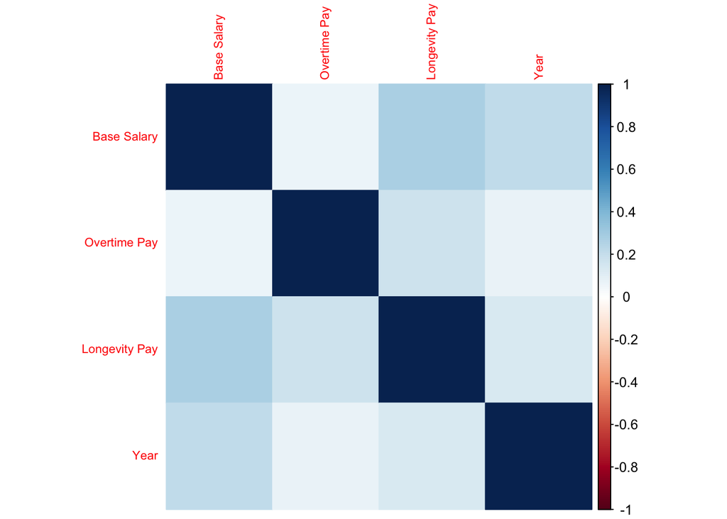

```r
corrplot(corr_matrix, method = "color", tl.cex = 0.7)
```

5. Saving the data_clean as csv file.

```r
# Saving data_clean
write_csv(data_clean, "Employee_Salaries_2019_to_2024.csv")
```